# Homework 1

Darien Lozon

January 9, 2019

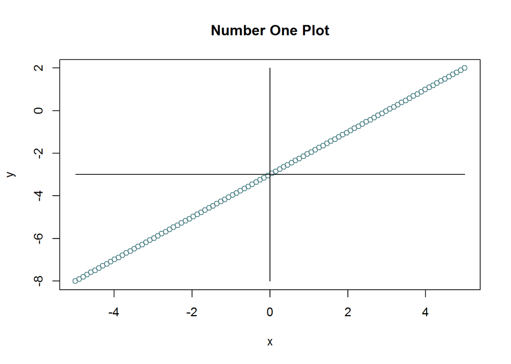

```r
#### CODE FOR NUMBER ONE ####
m <- 1
x <- seq(from=-5,to=5,length.out=100)
b <- -3
y <- m * x + b
plot(x=x,y=y,type='b',xlab="x",ylab="y",lty=5,col='cadetblue4',main='Number One Plot')
lines(x=c(0,0),y=c(-8,2),lty=1)
lines(x=c(-5,5),y=c(-3,-3))
```

#### 2. Assume you have a linear model with parameters $\beta$<sub>0</sub> = -3, $\beta$<sub>1</sub> = 1, and $\beta$<sub>2</sub> = 4. What is the interpretation of $\beta$<sub>0</sub>? Verify in R. See *Linear Models* slide 24 if you need help.

##### $\beta$<sub>0</sub> identifies the value of the response variable (y) when **both** predictor variables (x<sub>1</sub> and x<sub>2</sub>) equal zero.

```r
b0 <- -3
b1 <- 1
b2 <- 4
x1 <- 0
x2 <- 0
y <- b0 + b1 * x1 + b2 * x2
y
```

```
## [1] -3
```

#### 3. Assume the same linear model as in (2) above. Interpret slop coefficient $\beta$<sub>2</sub>. Verify this interpretation in R. See *Linear Models* slide 26 if you need help.

##### $\beta$<sub>2</sub> indicates the amount increase with each x<sub>2</sub> unit increased when x<sub>1</sub> is held **constant**.

```r
b0 <- -3
b1 <- 1
b2 <- 4
x1 <- 2
x2 <- 0
x2a <- 1
y <- b0 + b1 * x1 + b2 * x2
ya <- b0 + b1 * x1 + b2 * x2a
ya-y
```

```
## [1] 4
```

#### 4. Assume you have a linear model with a single categorical predictor. This categorical predictor can take 1 of 2 mutually exclusive levels. Demonstrate that the slope coefficient associated with 1 of the levels of this categorical predictor is the difference in the response variable y between the two levels of the predictor variable. If you need help, look to the interpretation of the slope coefficient on *Linear Models*, slide 18.

```r
b0 <- -2
b1 <- 3
xf <- 0
xm <- 1
ym <- b0 + b1 * xm
yf <- b0 + b1 * xf
ym-yf
```

```
## [1] 3
```